# Time Series Analysis and Forecasting

GiaPhuong

2025-04-10

```r
library(FinTS)
```

```r
library(ggplot2)
library(tidyverse)
library(cowplot)
library(forecast)
library(ggplot2)
library(dplyr)
library(Metrics)
library(tseries)
library(urca)
library(Hmisc)
library(car)
library(readxl)
```

# I. Chuỗi Doanh thu

```r
data1 <- read_excel("D:/Tài liệu các môn/Time series/PVC_data.xlsx",
    sheet = "Doanhthu")
```

## 1. Định dạng số liệu thời gian, tạo biến time và biến mùa vụ

```r
# Định dạng số liệu thời gian
doanhthu <- ts(data1$`Doanh số`, start=c(2010,1), frequency = 4)
```

```r
# Tạo biến xu thế thời gian
time <- seq_along(doanhthu)
summary(time)
```

```
##    Min. 1st Qu.  Median    Mean 3rd Qu.    Max.
##    1.00   15.75   30.50   30.50   45.25   60.00
```

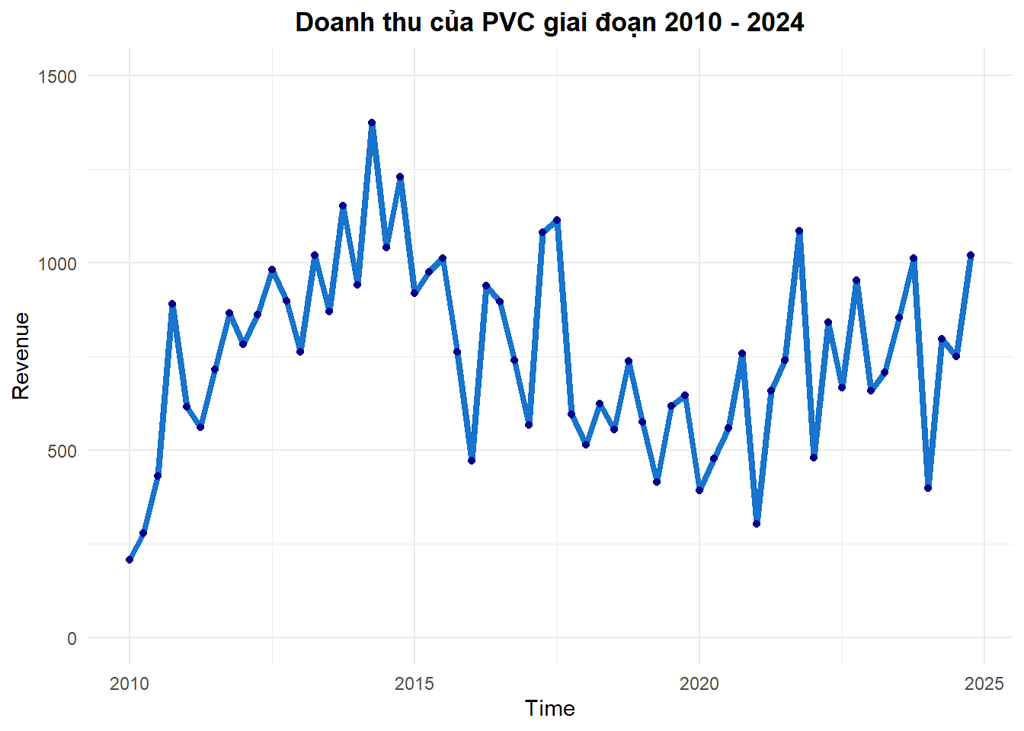

```r
# Đồ thị
dt_plot <- data.frame(Time = time(doanhthu), Revenue = doanhthu)
dt_plot %>% ggplot(aes(x=Time,y=Revenue)) +
  geom_line(col="dodgerblue3", size=1.5) +
  geom_point(col="darkblue") +
  theme_minimal() +
  labs(title="Doanh thu của PVC giai đoạn 2010 - 2024") +
  theme(plot.title = element_text(hjust = 0.5, face = "bold"))+
  scale_y_continuous(position="left", limits=c(0,1500))
```

## 2. Các mô hình dự báo

### Chia dữ liệu thành training set và validation set

```r
dt_train <- ts(doanhthu[1:56], start=c(2010,1), frequency = 4)
dt_valid<- ts(doanhthu[57:60], start=c(2024,1), frequency = 4)
t_train <- seq_along(dt_train)
summary(t_train)
```

```
##    Min. 1st Qu.  Median    Mean 3rd Qu.    Max.
##    1.00   14.75   28.50   28.50   42.25   56.00
```

### MÔ HÌNH 1: linear - linear:

```r
reg1 <- lm(dt_train~t_train)
summary(reg1)
```

```
##
## Call:
## lm(formula = dt_train ~ t_train)
##
## Residuals:
##     Min      1Q  Median      3Q     Max
## -584.06 -173.42   -4.79  171.72  602.88
##
## Coefficients:
##             Estimate Std. Error t value Pr(>|t|)
## (Intercept)  792.395     67.953  11.661 2.25e-16 ***
## t_train       -1.278      2.074  -0.616     0.54
## ---
## Signif. codes:  0 '***' 0.001 '**' 0.01 '*' 0.05 '.' 0.1 ' ' 1
##
## Residual standard error: 250.9 on 54 degrees of freedom
## Multiple R-squared:  0.006981,   Adjusted R-squared:  -0.01141
## F-statistic: 0.3796 on 1 and 54 DF,  p-value: 0.5404
```

```r
rmse(dt_train, fitted(reg1))
```

```
## [1] 246.338
```

```r
mape(dt_train, fitted(reg1))
```

```
## [1] 0.3465237
```

```r
rmse(dt_valid,predict(reg1, newdata = data.frame(t_train = 57:60)))
```

```
## [1] 225.1461
```

```r
mape(dt_valid,predict(reg1, newdata = data.frame(t_train = 57:60)))
```

```
## [1] 0.3120735
```

### MÔ HÌNH 2: linear - log:

$DT_t = \beta_0 + \beta_1*ln(t) + u_t$

```r
reg2 <- lm(dt_train~log(t_train))
summary(reg2)
```

```
##
## Call:
## lm(formula = dt_train ~ log(t_train))
##
## Residuals:
##     Min      1Q  Median      3Q     Max
## -481.08 -182.31  -12.28  179.23  623.33
##
## Coefficients:
##              Estimate Std. Error t value Pr(>|t|)
## (Intercept)    640.44     120.18   5.329 1.98e-06 ***
## log(t_train)    37.54      37.52   1.001    0.321
## ---
## Signif. codes:  0 '***' 0.001 '**' 0.01 '*' 0.05 '.' 0.1 ' ' 1
##
## Residual standard error: 249.4 on 54 degrees of freedom
## Multiple R-squared:  0.0182, Adjusted R-squared:  2.174e-05
## F-statistic: 1.001 on 1 and 54 DF,  p-value: 0.3215
```

```r
rmse(dt_train, fitted(reg2))
```

```
## [1] 244.9421
```

```r
mape(dt_train, fitted(reg2))
```

```
## [1] 0.3446632
```

```r
rmse(dt_valid,predict(reg2, newdata = data.frame(t_train = 57:60)))
```

```
## [1] 228.0703
```

```r
mape(dt_valid,predict(reg2, newdata = data.frame(t_train = 57:60)))
```

```
## [1] 0.3188413
```

### MÔ HÌNH 3: log - linear:

```r
reg3 <- lm(log(dt_train)~t_train)
summary(reg3)
```

```
##
## Call:
## lm(formula = log(dt_train) ~ t_train)
##
## Residuals:
##      Min       1Q   Median       3Q      Max
## -1.23938 -0.21458  0.05566  0.27752  0.65645
##
## Coefficients:
##              Estimate Std. Error t value Pr(>|t|)
## (Intercept)  6.572638   0.103791  63.326   <2e-16 ***
## t_train     -0.000270   0.003168  -0.085    0.932
## ---
## Signif. codes:  0 '***' 0.001 '**' 0.01 '*' 0.05 '.' 0.1 ' ' 1
##
## Residual standard error: 0.3832 on 54 degrees of freedom
## Multiple R-squared:  0.0001345,  Adjusted R-squared:  -0.01838
## F-statistic: 0.007262 on 1 and 54 DF,  p-value: 0.9324
```

```r
rmse(dt_train, exp(fitted(reg3)))
```

```
## [1] 251.248
```

```r
mape(dt_train, exp(fitted(reg3)))
```

```
## [1] 0.3318724
```

```r
rmse(dt_valid,exp(predict(reg3, newdata = data.frame(t_train = 57:60))))
```

```
## [1] 225.8557
```

```r
mape(dt_valid,exp(predict(reg3, newdata = data.frame(t_train = 57:60))))
```

```
## [1] 0.3142294
```

### MÔ HÌNH 4: log - log

$ln(DT_t) = \beta_0 + \beta_1 * ln(t) +u_t$

```r
reg4 <- lm(log(dt_train)~log(t_train))
summary(reg4)
```

```
##
## Call:
## lm(formula = log(dt_train) ~ log(t_train))
##
## Residuals:
##     Min      1Q  Median      3Q     Max
## -0.9267 -0.2260  0.0374  0.2944  0.6781
##
## Coefficients:
##              Estimate Std. Error t value Pr(>|t|)
## (Intercept)    6.2567     0.1794  34.879   <2e-16 ***
## log(t_train)   0.1002     0.0560   1.789   0.0793 .
## ---
## Signif. codes:  0 '***' 0.001 '**' 0.01 '*' 0.05 '.' 0.1 ' ' 1
##
## Residual standard error: 0.3723 on 54 degrees of freedom
## Multiple R-squared:  0.05593,    Adjusted R-squared:  0.03845
## F-statistic: 3.199 on 1 and 54 DF,  p-value: 0.07927
```

```r
rmse(dt_train, exp(fitted(reg4)))
```

```
## [1] 251.9493
```

```r
mape(dt_train, exp(fitted(reg4)))
```

```
## [1] 0.3267513
```

```r
rmse(dt_valid,exp(predict(reg4, newdata = data.frame(t_train = 57:60))))
```

```
## [1] 225.4105
```

```r
mape(dt_valid,exp(predict(reg4, newdata = data.frame(t_train = 57:60))))
```

```
## [1] 0.3143897
```

### Tạo biến giả mùa vụ theo quý

```r
s1<-rep(c(1,0,0,0),14)
s2<-rep(c(0,1,0,0),14)
s3<-rep(c(0,0,1,0),14)
s4<-rep(c(0,0,0,1),14)
```

### MÔ HÌNH 5: Hồi quy với biến giả mùa vụ

$DT_t = \beta_0 + \beta_1*s_2 + \beta_2*s_3 + \beta_3*s_4 + u_t$

```r
reg5 <- lm(dt_train ~ s2 + s3 + s4)
summary(reg5)
```

```
##
## Call:
## lm(formula = dt_train ~ s2 + s3 + s4)
##
## Residuals:
##     Min      1Q  Median      3Q     Max
## -493.84 -143.96  -12.19  180.45  600.78
##
## Coefficients:
##             Estimate Std. Error t value Pr(>|t|)
## (Intercept)   584.28      61.77   9.459 6.83e-13 ***
## s2            187.21      87.35   2.143  0.03680 *
## s3            204.33      87.35   2.339  0.02321 *
## s4            295.24      87.35   3.380  0.00138 **
## ---
## Signif. codes:  0 '***' 0.001 '**' 0.01 '*' 0.05 '.' 0.1 ' ' 1
##
## Residual standard error: 231.1 on 52 degrees of freedom
## Multiple R-squared:  0.1884, Adjusted R-squared:  0.1416
## F-statistic: 4.023 on 3 and 52 DF,  p-value: 0.01197
```

```r
rmse(dt_train, fitted(reg5))
```

```
## [1] 222.7039
```

```r
mape(dt_train, fitted(reg5))
```

```
## [1] 0.3036762
```

```r
rmse(dt_valid,predict(reg5)[1:4])
```

```
## [1] 118.7409
```

```r
mape(dt_valid,predict(reg5)[1:4])
```

```
## [1] 0.1723162
```

### MÔ HÌNH 6: Xu thế tuyến tính+ Mùa vụ dạng cộng

$DT_t = \beta_0 + \beta_1*t +\beta_2*s_2 + \beta_3*s_3 + \beta_4*s_4 + u_t$

```r
reg6 <- lm(dt_train ~ t_train + s2 + s3 + s4)
summary(reg6)
```

```
##
## Call:
## lm(formula = dt_train ~ t_train + s2 + s3 + s4)
##
## Residuals:
##     Min      1Q  Median      3Q     Max
## -538.50 -139.96  -16.56  163.50  583.60
##
## Coefficients:
##             Estimate Std. Error t value Pr(>|t|)
## (Intercept)  630.669     80.711   7.814 2.84e-10 ***
## t_train       -1.718      1.919  -0.895  0.37484
## s2           188.930     87.540   2.158  0.03564 *
## s3           207.764     87.603   2.372  0.02152 *
## s4           300.393     87.708   3.425  0.00122 **
## ---
## Signif. codes:  0 '***' 0.001 '**' 0.01 '*' 0.05 '.' 0.1 ' ' 1
##
## Residual standard error: 231.6 on 51 degrees of freedom
## Multiple R-squared:  0.2009, Adjusted R-squared:  0.1383
## F-statistic: 3.206 on 4 and 51 DF,  p-value: 0.02008
```

```r
rmse(dt_train, fitted(reg6))
```

```
## [1] 220.9742
```

```r
mape(dt_train, fitted(reg6))
```

```
## [1] 0.3013383
```

```r
rmse(dt_valid, predict(reg6, newdata = data.frame(t_train = 57:60,
                                                  s2=c(0,1,0,0),
                                                  s3=c(0,0,1,0),
                                                  s4=c(0,0,0,1))))
```

```
## [1] 123.2771
```

```r
mape(dt_valid,  predict(reg6, newdata = data.frame(t_train = 57:60,
                                                  s2=c(0,1,0,0),
                                                  s3=c(0,0,1,0),
                                                  s4=c(0,0,0,1))))
```

```
## [1] 0.1599344
```

### MÔ HÌNH 7: Xu thế tuyến tính + Mùa vụ, dạng nhân

$DT_t = \beta_0 + \beta_1*t +\beta_2*t*s_2 + \beta_3*t*s_3 + \beta_4*t*s_4 + u_t$

```r
reg7 <- lm(dt_train ~ t_train + I(t_train*s2) + I(t_train*s3)+ I(t_train*s4))
summary(reg7)
```

```
##
## Call:
## lm(formula = dt_train ~ t_train + I(t_train * s2) + I(t_train *
##     s3) + I(t_train * s4))
##
## Residuals:
##     Min      1Q  Median      3Q     Max
## -585.47 -141.98   13.16  172.55  593.06
##
## Coefficients:
##                 Estimate Std. Error t value Pr(>|t|)
## (Intercept)      799.186     63.872  12.512  < 2e-16 ***
## t_train           -6.658      2.655  -2.508  0.01538 *
## I(t_train * s2)    5.549      2.795   1.985  0.05249 .
## I(t_train * s3)    6.033      2.760   2.186  0.03342 *
## I(t_train * s4)    8.530      2.727   3.128  0.00291 **
## ---
## Signif. codes:  0 '***' 0.001 '**' 0.01 '*' 0.05 '.' 0.1 ' ' 1
##
## Residual standard error: 235.6 on 51 degrees of freedom
## Multiple R-squared:  0.1725, Adjusted R-squared:  0.1076
## F-statistic: 2.657 on 4 and 51 DF,  p-value: 0.04323
```

```r
rmse(dt_train, fitted(reg7))
```

```
## [1] 224.8777
```

```r
mape(dt_train, fitted(reg7))
```

```
## [1] 0.3097742
```

```r
rmse(dt_valid, predict(reg7, newdata = data.frame(t_train = 57:60,
                                                  s2=c(0,1,0,0),
                                                  s3=c(0,0,1,0),
                                                  s4=c(0,0,0,1))))
```

```
## [1] 63.38019
```

```r
mape(dt_valid, predict(reg7, newdata = data.frame(t_train = 57:60,
                                                  s2=c(0,1,0,0),
                                                  s3=c(0,0,1,0),
                                                  s4=c(0,0,0,1))))
```

```
## [1] 0.06377502
```

### MÔ HÌNH 8: Holt - Winter có mùa vụ dạng cộng

```r
hw.dt.train.a <- HoltWinters(dt_train, seasonal = "a")
hw.dt.train.a
```

```
## Holt-Winters exponential smoothing with trend and additive seasonal component.
##
## Call:
## HoltWinters(x = dt_train, seasonal = "a")
##
## Smoothing parameters:
##  alpha: 0.3250884
##  beta : 0.165585
##  gamma: 0.7236907
##
## Coefficients:
##          [,1]
## a   934.19825
## b    11.71475
## s1 -296.51479
## s2 -158.82354
## s3 -105.98938
## s4   86.79820
```

```r
rmse(dt_train, fitted(hw.dt.train.a)[,1])
```

```
## [1] 191.1194
```

```r
mape(dt_train, fitted(hw.dt.train.a)[,1])
```

```
## [1] 0.2185178
```

```r
rmse(dt_valid, forecast(hw.dt.train.a,h=4)$mean)
```

```
## [1] 140.1582
```

```r
mape(dt_valid, forecast(hw.dt.train.a,h=4)$mean)
```

```
## [1] 0.2085532
```

### MÔ HÌNH 9: Holt - Winter có mùa vụ dạng nhân

```r
hw.dt.train.m <- HoltWinters(dt_train, seasonal = "m")
hw.dt.train.m
```

```
## Holt-Winters exponential smoothing with trend and multiplicative seasonal component.
##
## Call:
## HoltWinters(x = dt_train, seasonal = "m")
##
## Smoothing parameters:
##  alpha: 0.3600538
##  beta : 0.1372853
##  gamma: 1
##
## Coefficients:
##            [,1]
## a  1152.5983021
## b    17.6979748
## s1    0.5630960
## s2    0.6406033
## s3    0.7181630
## s4    0.8772290
```

```r
rmse(dt_train, fitted(hw.dt.train.m)[,1])
```

```
## [1] 195.1028
```

```r
mape(dt_train, fitted(hw.dt.train.m)[,1])
```

```
## [1] 0.2247899
```

```r
rmse(dt_valid, forecast(hw.dt.train.m,h=4)$mean)
```

```
## [1] 146.5437
```

```r
mape(dt_valid, forecast(hw.dt.train.m,h=4)$mean)
```

```
## [1] 0.2273286
```

#Chọn MÔ HÌNH 7: Xu thế tuyến tính + Mùa vụ, dạng nhân để dự báo cho 2025

```r
#Mô hình Xu thế tuyến tính + Mùa vụ, dạng nhân trên toàn dữ liệu 2010-2024
reg7_1 <- lm(doanhthu ~ time + I(time*s2) + I(time*s3)+ I(time*s4))
summary(reg7_1)
```

```
##
## Call:
## lm(formula = doanhthu ~ time + I(time * s2) + I(time * s3) +
##     I(time * s4))
##
## Residuals:
##     Min      1Q  Median      3Q     Max
## -581.33 -141.65   15.89  127.28  591.76
##
## Coefficients:
##              Estimate Std. Error t value Pr(>|t|)
## (Intercept)   795.007     59.496  13.362  < 2e-16 ***
## time           -6.625      2.306  -2.873 0.005770 **
## I(time * s2)    5.820      2.430   2.395 0.020040 *
## I(time * s3)    6.063      2.401   2.525 0.014482 *
## I(time * s4)    8.923      2.374   3.758 0.000416 ***
## ---
## Signif. codes:  0 '***' 0.001 '**' 0.01 '*' 0.05 '.' 0.1 ' ' 1
##
## Residual standard error: 227.4 on 55 degrees of freedom
## Multiple R-squared:  0.2144, Adjusted R-squared:  0.1573
## F-statistic: 3.753 on 4 and 55 DF,  p-value: 0.009046
```

```r
#Dự báo cho 4 quý năm 2025
predict(reg7_1, newdata = data.frame(time = 61:64,
                                    s2=c(0,1,0,0),
                                    s3=c(0,0,1,0),
                                    s4=c(0,0,0,1)))
```

```
##        1        2        3        4
## 390.9003 745.0881 759.6182 942.0749
```

# II. Chuỗi giá và log return của PVC

```r
data2 <- read_excel("D:/Tài liệu các môn/Time series/PVC_data.xlsx",
    sheet = "Price")
names(data2)=c("Date","Price","LogReturn")
attach(data2)
```

## 1. Định dạng số liệu thời gian

```r
price <- ts(Price, start=1, frequency=1)
logreturn <- ts(LogReturn, start=1, frequency=1)
```

## 2. Plot

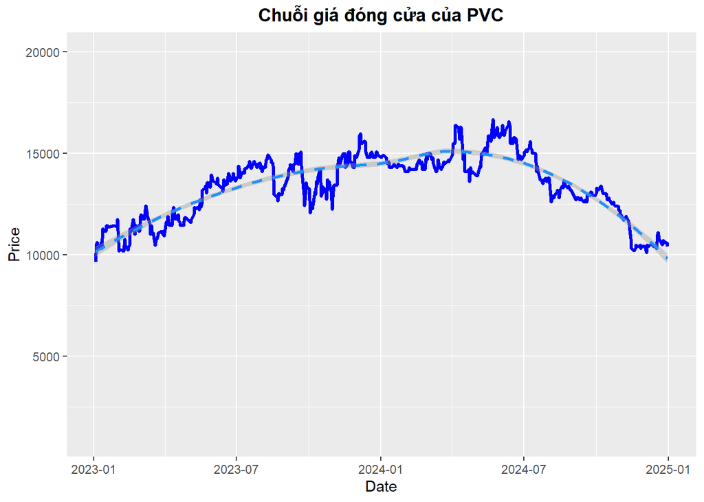

```r
plot1 <- data2 %>% ggplot(aes(x=Date,y=ts(Price))) +
  geom_line(color="blue1", size=1.2) +
  geom_smooth(linetype="dashed", color="#1E90FF")+
  labs(x="Date", y="Price") +
  labs(title="Chuỗi giá đóng cửa của PVC")+
  theme(plot.title = element_text(hjust = 0.5, face = "bold"))+
  scale_y_continuous(position="left", limits=c(1000,20000))
plot1
```

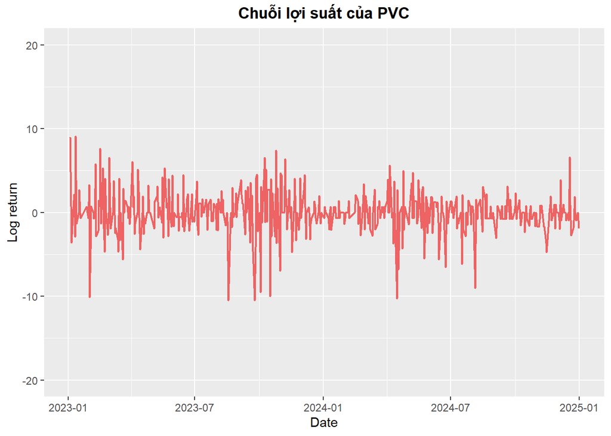

```r
plot2 <- data2 %>% ggplot(aes(x=Date, y=ts(LogReturn))) +
  geom_line(color="indianred2", size = 0.8) +
  scale_y_continuous(position="left", limits=c(-20,20)) +
  labs(x="Date", y="Log return")+
  labs(title="Chuỗi lợi suất của PVC")+
  theme(plot.title = element_text(hjust = 0.5, face = "bold"))
plot2
```

## 3. Kiểm định ADF ###Price

```r
summary(ur.df(price,type = "trend", selectlags = "AIC"))
```

```
##
## ###############################################
## # Augmented Dickey-Fuller Test Unit Root Test #
## ###############################################
##
## Test regression trend
##
##
## Call:
## lm(formula = z.diff ~ z.lag.1 + 1 + tt + z.diff.lag)
##
## Residuals:
##      Min       1Q   Median       3Q      Max
## -1529.83  -138.00    -1.53   161.14   936.75
##
## Coefficients:
##               Estimate Std. Error t value Pr(>|t|)
## (Intercept) 258.671595 123.914741   2.087   0.0374 *
## z.lag.1      -0.016899   0.009301  -1.817   0.0698 .
## tt           -0.130603   0.104376  -1.251   0.2114
## z.diff.lag   -0.114235   0.044491  -2.568   0.0105 *
## ---
## Signif. codes:  0 '***' 0.001 '**' 0.01 '*' 0.05 '.' 0.1 ' ' 1
##
## Residual standard error: 328.9 on 493 degrees of freedom
## Multiple R-squared:  0.02543,    Adjusted R-squared:  0.0195
## F-statistic: 4.288 on 3 and 493 DF,  p-value: 0.005305
##
##
## Value of test-statistic is: -1.8169 1.9096 2.8644
##
## Critical values for test statistics:
##       1pct  5pct 10pct
## tau3 -3.98 -3.42 -3.13
## phi2  6.15  4.71  4.05
## phi3  8.34  6.30  5.36
```

```r
summary(ur.df(price,type = "drift", selectlags = "AIC"))
```

```
##
## ###############################################
## # Augmented Dickey-Fuller Test Unit Root Test #
## ###############################################
##
## Test regression drift
##
##
## Call:
## lm(formula = z.diff ~ z.lag.1 + 1 + z.diff.lag)
##
## Residuals:
##      Min       1Q   Median       3Q      Max
## -1533.37  -140.98   -11.77   165.48   932.53
##
## Coefficients:
##               Estimate Std. Error t value Pr(>|t|)
## (Intercept) 250.626229 123.818649   2.024   0.0435 *
## z.lag.1      -0.018739   0.009189  -2.039   0.0420 *
## z.diff.lag   -0.109609   0.044363  -2.471   0.0138 *
## ---
## Signif. codes:  0 '***' 0.001 '**' 0.01 '*' 0.05 '.' 0.1 ' ' 1
##
## Residual standard error: 329.1 on 494 degrees of freedom
## Multiple R-squared:  0.02233,    Adjusted R-squared:  0.01837
## F-statistic: 5.642 on 2 and 494 DF,  p-value: 0.003777
##
##
## Value of test-statistic is: -2.0392 2.0792
##
## Critical values for test statistics:
##       1pct  5pct 10pct
## tau2 -3.44 -2.87 -2.57
## phi1  6.47  4.61  3.79
```

Chuỗi price không dừng

###Log return

```r
summary(ur.df(logreturn[2:499], type="trend"))
```

```
##
## ###############################################
## # Augmented Dickey-Fuller Test Unit Root Test #
## ###############################################
##
## Test regression trend
##
##
## Call:
## lm(formula = z.diff ~ z.lag.1 + 1 + tt + z.diff.lag)
##
## Residuals:
##      Min       1Q   Median       3Q      Max
## -11.0296  -1.0667   0.0235   1.2479   8.5172
##
## Coefficients:
##               Estimate Std. Error t value Pr(>|t|)
## (Intercept)  0.3484176  0.2248403   1.550   0.1219
## z.lag.1     -1.2204522  0.0669026 -18.242   <2e-16 ***
## tt          -0.0014064  0.0007824  -1.797   0.0729 .
## z.diff.lag   0.0847582  0.0443874   1.910   0.0568 .
## ---
## Signif. codes:  0 '***' 0.001 '**' 0.01 '*' 0.05 '.' 0.1 ' ' 1
##
## Residual standard error: 2.481 on 492 degrees of freedom
## Multiple R-squared:  0.5656, Adjusted R-squared:  0.563
## F-statistic: 213.6 on 3 and 492 DF,  p-value: < 2.2e-16
##
##
## Value of test-statistic is: -18.2422 110.9359 166.3953
##
## Critical values for test statistics:
##       1pct  5pct 10pct
## tau3 -3.98 -3.42 -3.13
## phi2  6.15  4.71  4.05
## phi3  8.34  6.30  5.36
```

```r
summary(ur.df(logreturn[2:499], type="drift"))
```

```
##
## ###############################################
## # Augmented Dickey-Fuller Test Unit Root Test #
## ###############################################
##
## Test regression drift
##
##
## Call:
## lm(formula = z.diff ~ z.lag.1 + 1 + z.diff.lag)
##
## Residuals:
##      Min       1Q   Median       3Q      Max
## -10.9151  -1.0515  -0.0547   1.2563   8.8625
##
## Coefficients:
##              Estimate Std. Error t value Pr(>|t|)
## (Intercept) -0.002615   0.111670  -0.023   0.9813
## z.lag.1     -1.207894   0.066687 -18.113   <2e-16 ***
## z.diff.lag   0.078107   0.044333   1.762   0.0787 .
## ---
## Signif. codes:  0 '***' 0.001 '**' 0.01 '*' 0.05 '.' 0.1 ' ' 1
##
## Residual standard error: 2.487 on 493 degrees of freedom
## Multiple R-squared:  0.5628, Adjusted R-squared:  0.561
## F-statistic: 317.3 on 2 and 493 DF,  p-value: < 2.2e-16
##
##
## Value of test-statistic is: -18.1128 164.0461
##
## Critical values for test statistics:
##       1pct  5pct 10pct
## tau2 -3.44 -2.87 -2.57
## phi1  6.47  4.61  3.79
```

```r
summary(ur.df(logreturn[2:499], type="none"))
```

```
##
## ###############################################
## # Augmented Dickey-Fuller Test Unit Root Test #
## ###############################################
##
## Test regression none
##
##
## Call:
## lm(formula = z.diff ~ z.lag.1 - 1 + z.diff.lag)
##
## Residuals:
##      Min       1Q   Median       3Q      Max
## -10.9177  -1.0541  -0.0573   1.2537   8.8599
##
## Coefficients:
##            Estimate Std. Error t value Pr(>|t|)
## z.lag.1    -1.20790    0.06662 -18.132   <2e-16 ***
## z.diff.lag  0.07812    0.04429   1.764   0.0784 .
## ---
## Signif. codes:  0 '***' 0.001 '**' 0.01 '*' 0.05 '.' 0.1 ' ' 1
##
## Residual standard error: 2.484 on 494 degrees of freedom
## Multiple R-squared:  0.5628, Adjusted R-squared:  0.561
## F-statistic: 317.9 on 2 and 494 DF,  p-value: < 2.2e-16
##
##
## Value of test-statistic is: -18.1317
##
## Critical values for test statistics:
##       1pct  5pct 10pct
## tau1 -2.58 -1.95 -1.62
```

Chuỗi logreturn dừng vây quanh 0

###Sai phân của Price

```r
summary(ur.df(diff(price),type = "trend"))
```

```
##
## ###############################################
## # Augmented Dickey-Fuller Test Unit Root Test #
## ###############################################
##
## Test regression trend
##
##
## Call:
## lm(formula = z.diff ~ z.lag.1 + 1 + tt + z.diff.lag)
##
## Residuals:
##      Min       1Q   Median       3Q      Max
## -1523.71  -141.03     2.02   163.45   916.29
##
## Coefficients:
##             Estimate Std. Error t value Pr(>|t|)
## (Intercept) 42.83490   29.78625   1.438   0.1510
## z.lag.1     -1.22326    0.06709 -18.234   <2e-16 ***
## tt          -0.17273    0.10364  -1.667   0.0962 .
## z.diff.lag   0.08745    0.04460   1.961   0.0505 .
## ---
## Signif. codes:  0 '***' 0.001 '**' 0.01 '*' 0.05 '.' 0.1 ' ' 1
##
## Residual standard error: 329 on 492 degrees of freedom
## Multiple R-squared:  0.5657, Adjusted R-squared:  0.5631
## F-statistic: 213.7 on 3 and 492 DF,  p-value: < 2.2e-16
##
##
## Value of test-statistic is: -18.234 110.8323 166.2433
##
## Critical values for test statistics:
##       1pct  5pct 10pct
## tau3 -3.98 -3.42 -3.13
## phi2  6.15  4.71  4.05
## phi3  8.34  6.30  5.36
```

```r
summary(ur.df(diff(price),type = "drift"))
```

```
##
## ###############################################
## # Augmented Dickey-Fuller Test Unit Root Test #
## ###############################################
##
## Test regression drift
##
##
## Call:
## lm(formula = z.diff ~ z.lag.1 + 1 + z.diff.lag)
##
## Residuals:
##      Min       1Q   Median       3Q      Max
## -1538.71  -147.00    -7.85   173.12   958.62
##
## Coefficients:
##             Estimate Std. Error t value Pr(>|t|)
## (Intercept) -0.27345   14.79797  -0.018   0.9853
## z.lag.1     -1.21254    0.06690 -18.125   <2e-16 ***
## z.diff.lag   0.08182    0.04456   1.836   0.0669 .
## ---
## Signif. codes:  0 '***' 0.001 '**' 0.01 '*' 0.05 '.' 0.1 ' ' 1
##
## Residual standard error: 329.6 on 493 degrees of freedom
## Multiple R-squared:  0.5633, Adjusted R-squared:  0.5615
## F-statistic:   318 on 2 and 493 DF,  p-value: < 2.2e-16
##
##
## Value of test-statistic is: -18.1252 164.2673
##
## Critical values for test statistics:
##       1pct  5pct 10pct
## tau2 -3.44 -2.87 -2.57
## phi1  6.47  4.61  3.79
```

```r
summary(ur.df(diff(price),type = "none"))
```

```
##
## ###############################################
## # Augmented Dickey-Fuller Test Unit Root Test #
## ###############################################
##
## Test regression none
##
##
## Call:
## lm(formula = z.diff ~ z.lag.1 - 1 + z.diff.lag)
##
## Residuals:
##      Min       1Q   Median       3Q      Max
## -1538.98  -147.27    -8.12   172.84   958.35
##
## Coefficients:
##            Estimate Std. Error t value Pr(>|t|)
## z.lag.1    -1.21255    0.06683 -18.144   <2e-16 ***
## z.diff.lag  0.08182    0.04451   1.838   0.0666 .
## ---
## Signif. codes:  0 '***' 0.001 '**' 0.01 '*' 0.05 '.' 0.1 ' ' 1
##
## Residual standard error: 329.2 on 494 degrees of freedom
## Multiple R-squared:  0.5633, Adjusted R-squared:  0.5615
## F-statistic: 318.6 on 2 and 494 DF,  p-value: < 2.2e-16
##
##
## Value of test-statistic is: -18.1439
##
## Critical values for test statistics:
##       1pct  5pct 10pct
## tau1 -2.58 -1.95 -1.62
```

Sai phân của Price dừng vây quanh 0

##4. Xem ACF, PACF của chuỗi Log return

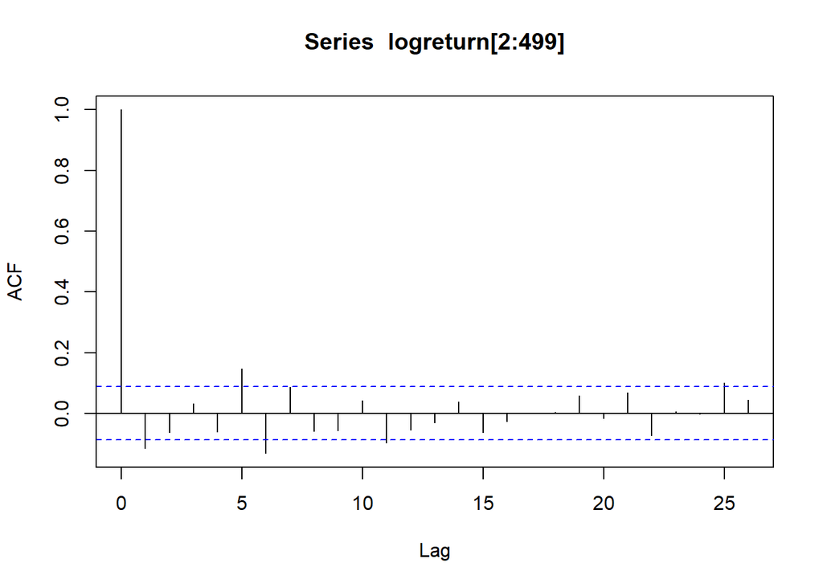

```r
acf(logreturn[2:499])
```

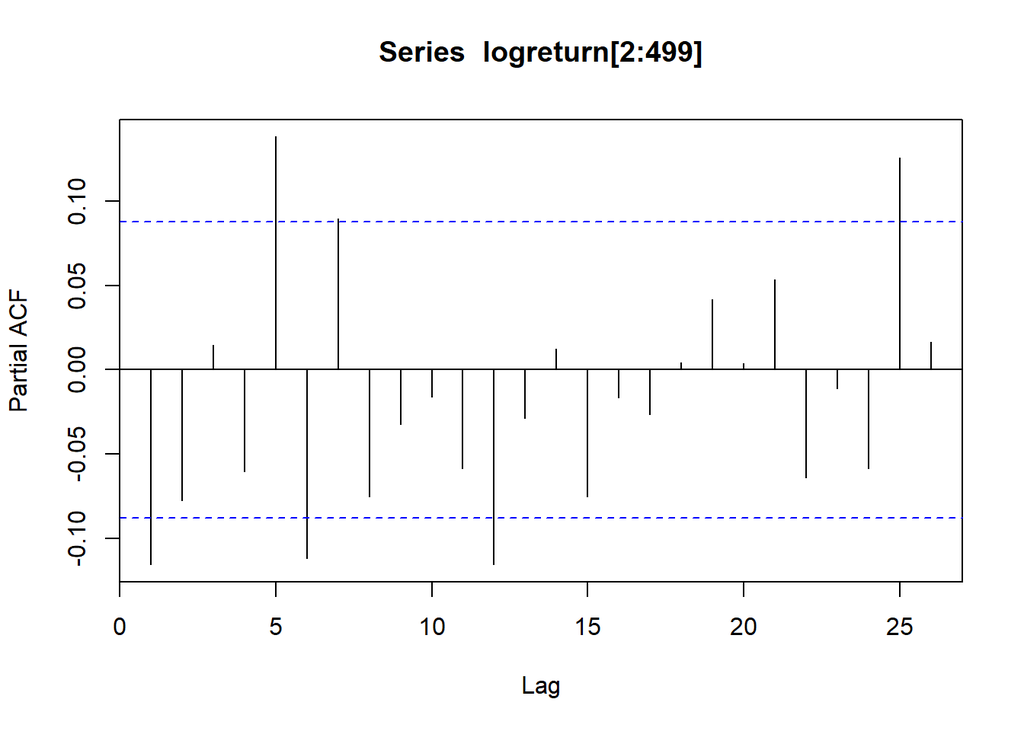

```r
pacf(logreturn[2:499])
```

Đề xuất mô hình: ARIMA(1,0,5), ARIMA(5,0,1)

### 4.1. Mô hình ARIMA

```r
# ARIMA(1,0,5)
reg.log.arima105 <- arima(logreturn[2:499], order = c(1,0,5),include.mean=FALSE)
summary(reg.log.arima105)
```

```
##
## Call:
## arima(x = logreturn[2:499], order = c(1, 0, 5), include.mean = FALSE)
##
## Coefficients:
##           ar1     ma1      ma2      ma3      ma4     ma5
##       -0.6044  0.5231  -0.1516  -0.0110  -0.0144  0.1297
## s.e.   0.1474  0.1495   0.0512   0.0565   0.0520  0.0559
##
## sigma^2 estimated as 6.035:  log likelihood = -1154.38,  aic = 2322.76
##
## Training set error measures:
##                      ME     RMSE      MAE MPE MAPE      MASE         ACF1
## Training set 0.01674591 2.456576 1.696338 NaN  Inf 0.6224458 -0.006078244
```

```r
# ARIMA(5,0,1)
reg.log.arima501 <- arima(logreturn[2:499], order = c(5,0,1),include.mean=FALSE)
summary(reg.log.arima501)
```

```
##
## Call:
## arima(x = logreturn[2:499], order = c(5, 0, 1), include.mean = FALSE)
##
## Coefficients:
##           ar1      ar2      ar3      ar4     ar5     ma1
##       -0.7550  -0.1632  -0.0349  -0.0366  0.1159  0.6701
## s.e.   0.1187   0.0583   0.0581   0.0567  0.0521  0.1139
##
## sigma^2 estimated as 6.007:  log likelihood = -1153.21,  aic = 2320.41
##
## Training set error measures:
##                      ME     RMSE      MAE MPE MAPE      MASE        ACF1
## Training set 0.01749898 2.450881 1.694231 NaN  Inf 0.6216724 0.001030843
```

### 4.2 Xem tính dừng qua nghiệm nghịch đảo

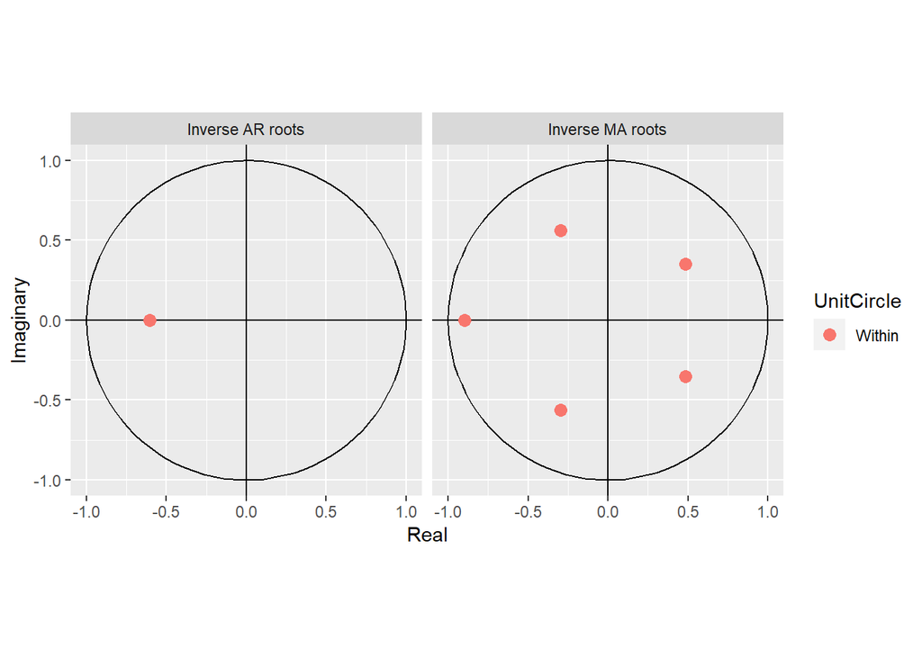

```r
autoplot(reg.log.arima105)
```

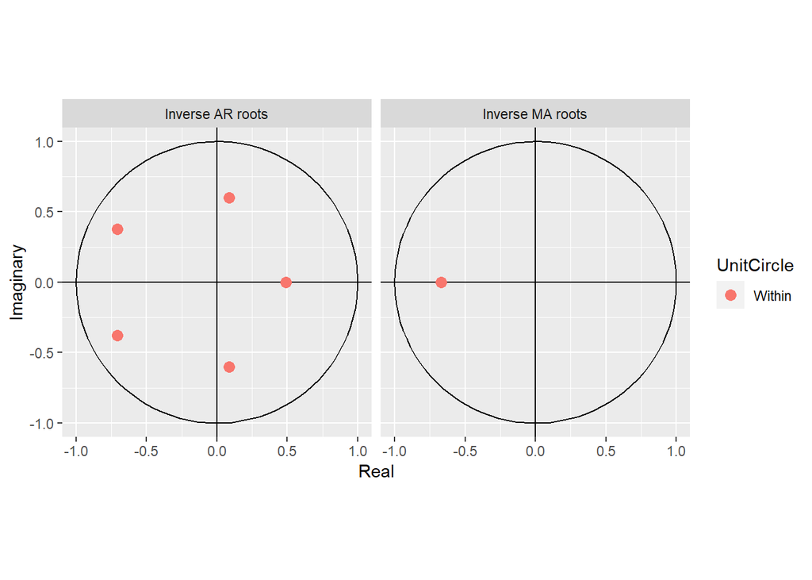

```r
autoplot(reg.log.arima501)
```

### 4.3 Kiểm định tính nhiễu trắng của phần dư

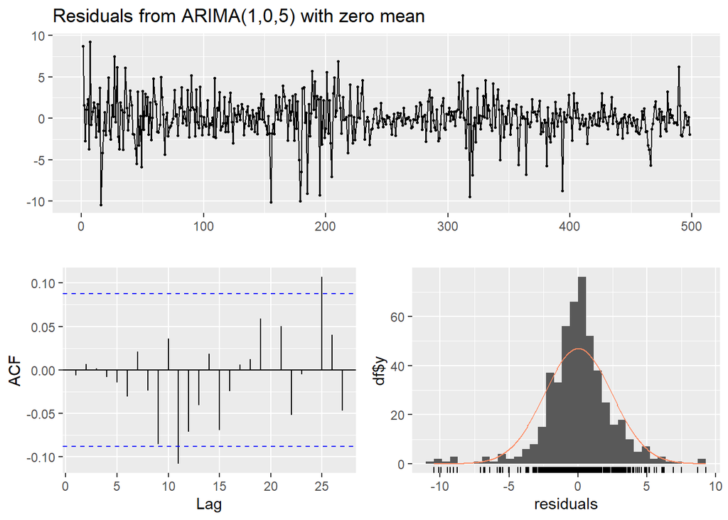

```
##
##  Ljung-Box test
##
## data:  Residuals from ARIMA(1,0,5) with zero mean
## Q* = 5.5502, df = 4, p-value = 0.2354
##
## Model df: 6.   Total lags used: 10
```

```r
checkresiduals(reg.log.arima105)
```

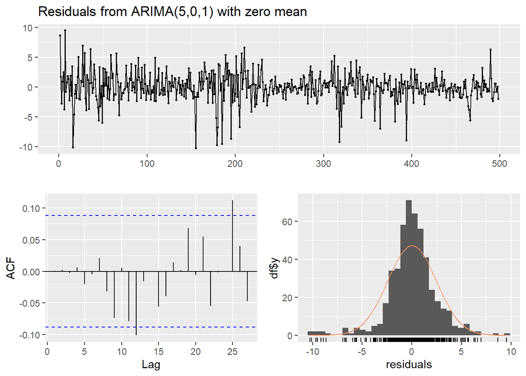

```
##
##  Ljung-Box test
##
## data:  Residuals from ARIMA(5,0,1) with zero mean
## Q* = 3.7651, df = 4, p-value = 0.4387
##
## Model df: 6.   Total lags used: 10
```

```r
checkresiduals(reg.log.arima501)
```

### 4.4 Dự báo logreturn

```r
logf.arima501<-forecast(reg.log.arima501,h=10)
logf.arima501
```

```
##     Point Forecast     Lo 80    Hi 80     Lo 95    Hi 95
## 499    0.394899210 -2.746032 3.535830 -4.408740 5.198539
## 500    0.046994240 -3.105260 3.199249 -4.773963 4.867951
## 501   -0.142259261 -3.309815 3.025297 -4.986618 4.702100
## 502    0.155617635 -3.016429 3.327664 -4.695609 5.006844
## 503   -0.331139906 -3.508414 2.846134 -5.190362 4.528082
## 504    0.273650714 -2.941904 3.489205 -4.644115 5.191417
## 505   -0.147368185 -3.384053 3.089317 -5.097451 4.802715
## 506    0.055996626 -3.184751 3.296745 -4.900300 5.012293
## 507    0.002360678 -3.238825 3.243547 -4.954605 4.959327
## 508   -0.054162740 -3.295373 3.187047 -5.011166 4.902841
```

#### Tính sai số

```r
data3 <- read_excel("D:/Tài liệu các môn/Time series/PVC_data.xlsx",
    sheet = "Real_Price")
names(data3)=c("Date","real_Price","real_LogReturn")
attach(data3)
real_log <- ts(data3$real_LogReturn, start=500, end=509, frequency=1)
```

```r
# ARIMA(5,0,1)
rmse(real_log, logf.arima501$mean)
```

```
## [1] 1.054402
```

```r
mape(real_log, logf.arima501$mean)
```

```
## [1] Inf
```

### 6.5. Suy ra dự báo giá cổ phiếu 10 phiên đầu năm 2025

```r
logf501 <- data.frame(logf.arima501$mean)
```

```r
real_price <- ts(data3$real_Price, start=1, end=10, frequency=1)
```

```r
# ARIMA(5,0,1)
price_f1 <- exp(logf501[1,1]/100)*price[499]  # Giá phiên 1

k <- nrow(logf501)
price_f <- rep(0,k)
# Tạo vòng lặp để tính giá
for(i in 2:k){
  price_f[1] <- price_f1
 price_f[i] <- exp(logf501[i,1]/100)*price_f[i-1]
}
price_f    # Giá 10 phiên
```

```
##  [1] 10441.15 10446.06 10431.21 10447.45 10412.92 10441.45 10426.07 10431.91
##  [9] 10432.16 10426.51
```

```r
# sai số ARIMA(5,0,1)
rmse(real_price, price_f)
```

```
## [1] 229.2686
```

```r
mape(real_price, price_f)
```

```
## [1] 0.01973439
```

## 5. Xem ACF, PACF của sai phân price

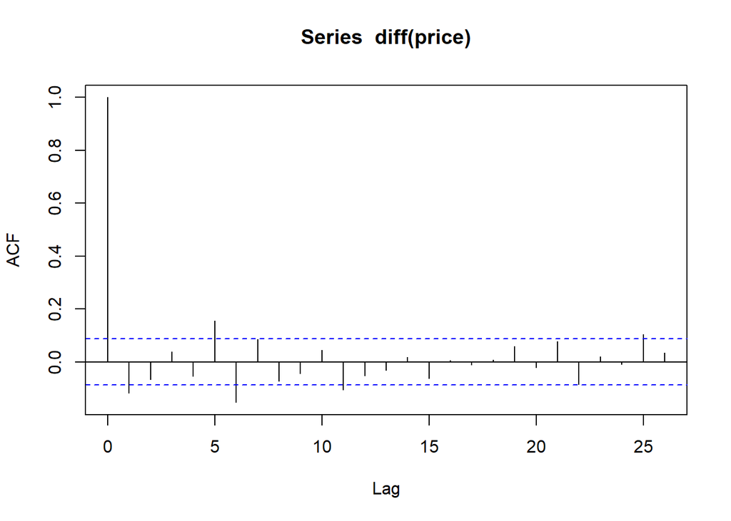

```r
acf(diff(price))
```

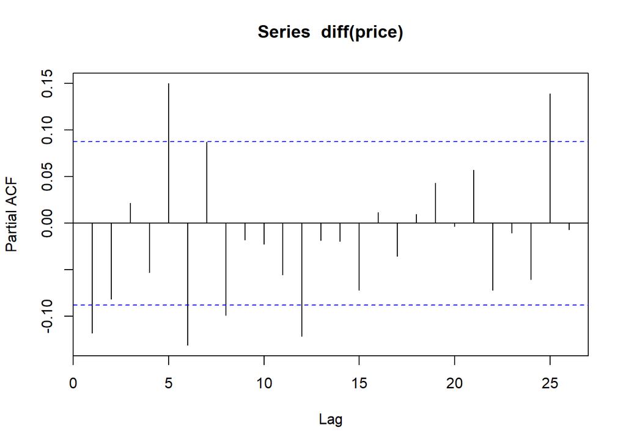

```r
pacf(diff(price))
```

Đề xuất mô hình: ARIMA(1,1,5), ARIMA(5,1,1)

### 5.1. Mô hình ARIMA

```r
# ARIMA(1,1,5)
reg.price.arima115 <- arima(price, order = c(1,1,5))
summary(reg.price.arima115)
```

```
##
## Call:
## arima(x = price, order = c(1, 1, 5))
##
## Coefficients:
##           ar1     ma1      ma2     ma3      ma4     ma5
##       -0.6261  0.5545  -0.1566  0.0000  -0.0036  0.1396
## s.e.   0.1222  0.1244   0.0512  0.0568   0.0528  0.0548
##
## sigma^2 estimated as 103664:  log likelihood = -3582.54,  aic = 7179.07
##
## Training set error measures:
##                    ME     RMSE      MAE         MPE     MAPE      MASE
## Training set 1.643253 321.6463 223.7773 -0.01551058 1.703251 0.9917035
##                      ACF1
## Training set -0.007314143
```

```r
# ARIMA(5,1,1)
reg.price.arima511 <- arima(price, order = c(5,1,1))
summary(reg.price.arima511)
```

```
##
## Call:
## arima(x = price, order = c(5, 1, 1))
##
## Coefficients:
##           ar1      ar2      ar3      ar4     ar5     ma1
##       -0.7880  -0.1709  -0.0290  -0.0218  0.1303  0.7102
## s.e.   0.1048   0.0584   0.0584   0.0572  0.0516  0.0992
##
## sigma^2 estimated as 103173:  log likelihood = -3581.31,  aic = 7176.62
##
## Training set error measures:
##                    ME     RMSE      MAE         MPE     MAPE      MASE
## Training set 1.725283 320.8836 223.3879 -0.01550499 1.699545 0.9899777
##                     ACF1
## Training set 0.001331992
```

### 5.2 Xem tính dừng qua nghiệm nghịch đảo

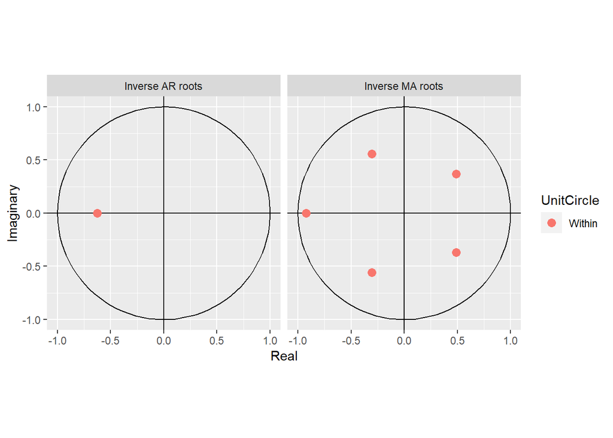

```r
autoplot(reg.price.arima115)
```

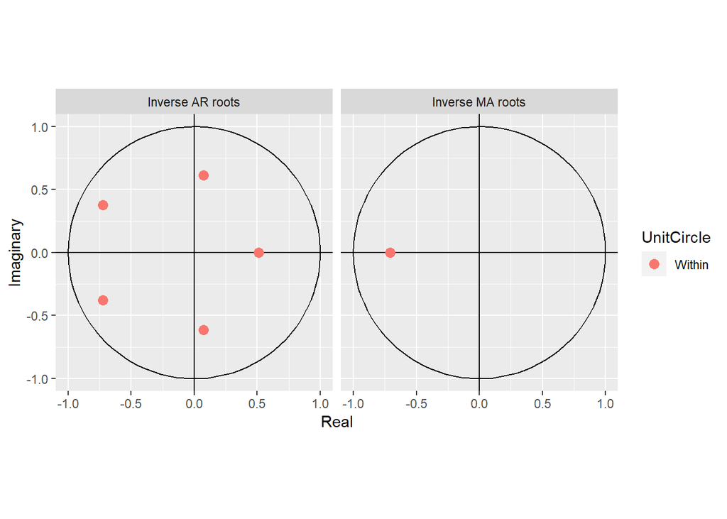

```r
autoplot(reg.price.arima511)
```

### 5.3 Kiểm định tính nhiễu trắng của phần dư

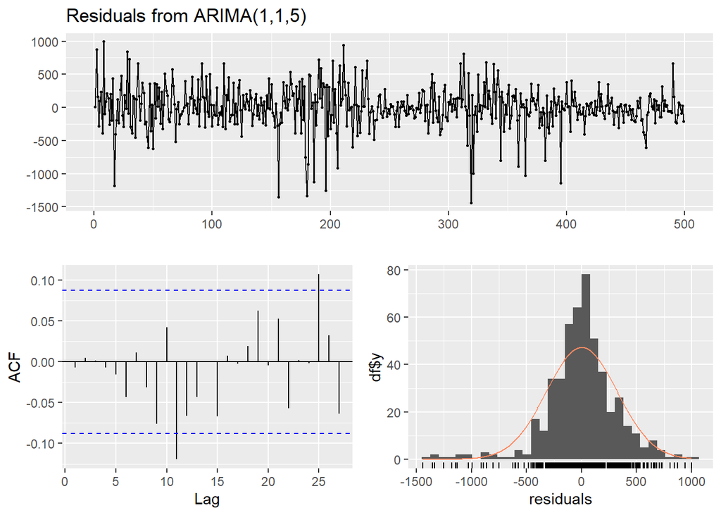

```
##
##  Ljung-Box test
##
## data:  Residuals from ARIMA(1,1,5)
## Q* = 5.5915, df = 4, p-value = 0.2318
##
## Model df: 6.   Total lags used: 10
```

```r
checkresiduals(reg.price.arima115)
```

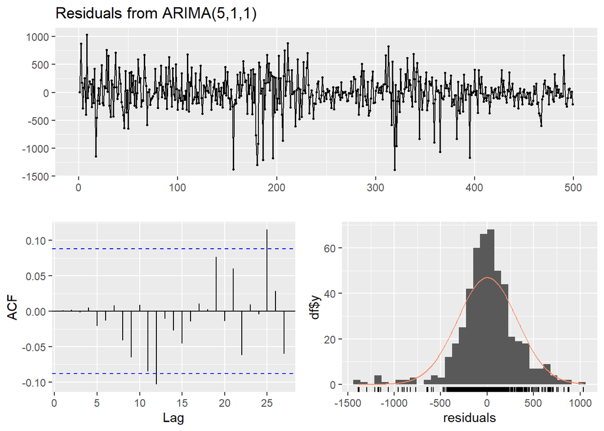

```
##
##  Ljung-Box test
##
## data:  Residuals from ARIMA(5,1,1)
## Q* = 3.4288, df = 4, p-value = 0.4888
##
## Model df: 6.   Total lags used: 10
```

```r
checkresiduals(reg.price.arima511)
```

### 5.4 Dự báo giá

```r
pricef.arima511 <- forecast(reg.price.arima511,h=10)
pricef.arima511
```

```
##     Point Forecast     Lo 80    Hi 80    Lo 95    Hi 95
## 500       10438.50 10026.856 10850.14 9808.947 11068.05
## 501       10444.52  9884.545 11004.50 9588.112 11300.93
## 502       10425.96  9773.681 11078.23 9428.387 11423.53
## 503       10442.79  9696.013 11189.57 9300.692 11584.89
## 504       10405.63  9584.941 11226.31 9150.497 11660.75
## 505       10437.46  9520.347 11354.57 9034.858 11840.06
## 506       10419.43  9436.033 11402.82 8915.454 11923.40
## 507       10426.49  9372.159 11480.81 8814.033 12038.94
## 508       10426.09  9308.096 11544.08 8716.267 12135.91
## 509       10420.18  9242.193 11598.17 8618.604 12221.76
```

#### Tính sai số

```r
real_close <- ts(data3$real_Price, start=500, end=509, frequency=1)
```

```r
# ARIMA(5,1,1)
rmse(real_close, pricef.arima511$mean)
```

```
## [1] 225.2126
```

```r
mape(real_close, pricef.arima511$mean)
```

```
## [1] 0.01944788
```

#Plot

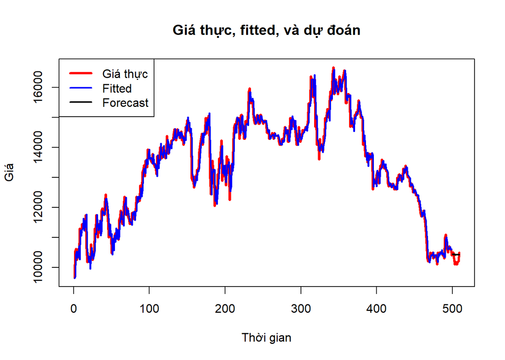

```r
#ARIMA (5,1,1)
# Bước 1: Chuẩn bị dữ liệu
## Ghép chuỗi giá thực lại thành 1 vector
all_Price <- c(price, real_close)
##Tính toán giá fitted và forecast
fitted<-fitted(reg.price.arima511)
forecast<-pricef.arima511$mean

# Bước 2: vẽ giá thực
plot(1:509, all_Price, type = "l", col = "red", lwd = 3,lty=1,
     xlab = "Thời gian", ylab = "Giá", main = "Giá thực, fitted, và dự đoán")

# Bước 3: thêm fitted (đường xanh)
lines(1:499, fitted, type = "l", col = "blue", lwd = 2, lty = 1)

# Bước 4: thêm forecast (đường đen)
lines(500:509, forecast, type = "l", col = "black", lwd = 2, lty = 1)

# Bước 5: thêm chú thích
legend("topleft",
       legend = c("Giá thực", "Fitted", "Forecast"),
       col = c("red", "blue", "black"),
       lty = c(1, 1, 1),
       lwd = c(3,2,2))
```

## 6. Mô hình ARCH - GARCH

```r
# Kiểm tra sự thay đổi phương sai
library(fUnitRoots)
ArchTest(logreturn[2:499])
```

```
##
##  ARCH LM-test; Null hypothesis: no ARCH effects
##
## data:  logreturn[2:499]
## Chi-squared = 63.632, df = 12, p-value = 4.875e-09
```

```r
# Xây dựng mô hình GARCH
library(rugarch)
garch_spec <- ugarchspec(
  mean.model = list(armaOrder = c(5, 1)),
  variance.model = list(model = "sGARCH", garchOrder = c(1, 1)),
  distribution.model = "norm"
)
```

```r
garch_fit <- ugarchfit(spec = garch_spec, data = logreturn[2:499])
summary(garch_fit)
```

```
##    Length     Class      Mode
##         1 uGARCHfit        S4
```

```r
coef(garch_fit)  # Trích xuất các tham số của mô hình
```

```
##          mu         ar1         ar2         ar3         ar4         ar5
## -0.06073097 -1.01168222 -0.18879876 -0.08041550 -0.04941130 -0.02197967
##         ma1       omega      alpha1       beta1
##  0.96646594  0.17070152  0.07233003  0.89813929
```

```r
# Dự báo 10 bước tới
forecast_result <- ugarchforecast(garch_fit, n.ahead = 10)

# Hiển thị kết quả dự báo
forecast_result
```

```
##
## *------------------------------------*
## *       GARCH Model Forecast         *
## *------------------------------------*
## Model: sGARCH
## Horizon: 10
## Roll Steps: 0
## Out of Sample: 0
##
## 0-roll forecast [T0=1971-05-14]:
##        Series Sigma
## T+1  -0.14160 2.006
## T+2   0.40642 2.019
## T+3  -0.35347 2.031
## T+4   0.24352 2.043
## T+5  -0.30631 2.055
## T+6   0.13251 2.066
## T+7  -0.23013 2.077
## T+8   0.08531 2.087
## T+9  -0.18659 2.097
## T+10  0.04850 2.107
```

```r
garch_logf <- forecast_result@forecast$seriesFor
garch_logf
```

```
##       1971-05-14
## T+1  -0.14159819
## T+2   0.40641918
## T+3  -0.35347484
## T+4   0.24352238
## T+5  -0.30630689
## T+6   0.13250725
## T+7  -0.23013184
## T+8   0.08531472
## T+9  -0.18659262
## T+10  0.04849977
```

```r
rmse(real_log,garch_logf)
```

```
## [1] 1.436455
```

```r
mape(real_log,garch_logf)
```

```
## [1] Inf
```

```r
#Tinh gia
price_f1 <- exp(garch_logf[1,1]/100)*price[499]  # Giá phiên 1

k <- nrow(garch_logf)
price_f <- rep(0,k)
# Tạo vòng lặp để tính giá
for(i in 2:k){
  price_f[1] <- price_f1
 price_f[i] <- exp(garch_logf[i,1]/100)*price_f[i-1]
}
price_f
```

```
##  [1] 10385.28 10427.58 10390.78 10416.12 10384.26 10398.03 10374.13 10382.98
##  [9] 10363.63 10368.66
```

```r
rmse(real_close,price_f)
```

```
## [1] 200.5015
```

```r
mape(real_close,price_f)
```

```
## [1] 0.01791407
```

#Du bao rui ro

```r
forecast_result@forecast$sigmaFor
```

```
##      1971-05-14
## T+1    2.005634
## T+2    2.018534
## T+3    2.030975
## T+4    2.042976
## T+5    2.054555
## T+6    2.065731
## T+7    2.076519
## T+8    2.086935
## T+9    2.096994
## T+10   2.106711
```

```r
P0 <- price[499]  # giá cuối cùng thực tế

# Lấy forecast volatility (%)
sigma <- as.numeric(forecast_result@forecast$sigmaFor)

# Chuyển về đơn vị chuẩn (không phải %)
sigma <- sigma / 100

# Tính phương sai giá
price_var <- (P0^2) * sigma^2

# Tính độ lệch chuẩn giá
price_sd <- P0 * sigma

# Tạo bảng kết quả
forecast_df <- data.frame(
  Step = paste0("T+", 1:10),
  Sigma = round(sigma, 4),
  PriceVariance = round(price_var, 4),
  PriceSD = round(price_sd, 4)
)

forecast_df
```

| Step | Sigma | PriceVariance | PriceSD |
| --- | --- | --- | --- |
| T+1 | 0.0201 | 43508.08 | 208.5859 |
| T+2 | 0.0202 | 44069.57 | 209.9275 |
| T+3 | 0.0203 | 44614.47 | 211.2214 |
| T+4 | 0.0204 | 45143.28 | 212.4695 |
| T+5 | 0.0205 | 45656.48 | 213.6738 |
| T+6 | 0.0207 | 46154.52 | 214.8360 |
| T+7 | 0.0208 | 46637.85 | 215.9580 |
| T+8 | 0.0209 | 47106.92 | 217.0413 |
| T+9 | 0.0210 | 47562.12 | 218.0874 |
| T+10 | 0.0211 | 48003.89 | 219.0979 |